# L16 - Causality & Experiments

## Lecture Goals

- Understand concept of *causality*
  - Distinguish causation from association
  - Beware of *confounding* in observational studies
- Use *control variables* to limit confounding
- Use *experiments* to assess causal relations
- Readings
  - [ISRS](https://www.openintro.org/download.php?file=isrs1_tablet&referrer=/stat/textbook.php): ch. 1.3-5

## Association & Causation

- *Association/Dependence* describes any *statistical* relationship between variables
  - E.g. if \(X\) is large, then \(Y\) will *likely* be large, & vice-versa
  - Association is *symmetric* (\(X \leftrightarrow Y\))
- *Causation/Causality* describes **cause-effect** relationship between variables
  - E.g. \(X\) is (partially) responsible for changes in \(Y\)
  - Causation is *asymmetric* (\(X \rightarrow Y\))

## Association vs Causation

- Type of relation determines its *practical use*
- Associations used for *prediction*
  - Just *observe* event & try to *predict* its outcome (\(Y\)) based on available information (\(X\))
- Causual relationships used for *intervention*
  - Can actually *manipulate* (\(X\)) in order to *change* event's outcome (\(Y\))

## Regression

- Regression model describes *"relationship"* between response (\(Y\)) and explanatory (\(X\)) variables
- Plug-in nature of regression function (\(X\rightarrow f(X)=\hat{Y}\)) suggests that \(X\) *causes* \(Y\)
- Causal interpretation is generally **incorrect**
  - Unless data come from *experiment*, i.e. generated by intervention

## Example

- Consider hypothetical causal model with variables
  - \(X\): ice cream sales
  - \(Y\): wildfires area
  - \(Z\): average temperature

and (linear) causal relationships

\[X = a + b Z + \textrm{err}_X, \quad Y = c + d Z + \textrm{err}_Y\]

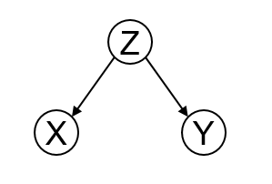

## Example

- Simulate data from causal model (no intervention)

```r
sim = tibble( Z = 30 + 10 * rnorm(100),
              X = 20 + 3 * Z + 20*rnorm(100),
              Y = 50 + 1 * Z + 10*rnorm(100))
```

- `rnorm()` generates real random numbers

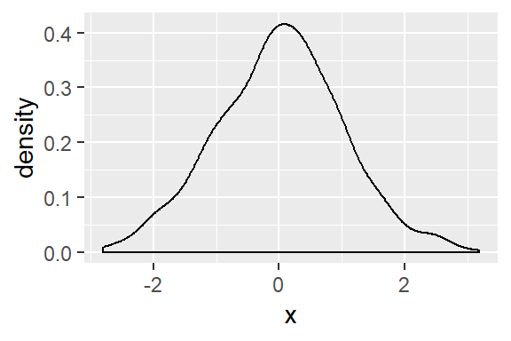

```r
tibble(x=rnorm(1000)) %>% ggplot(aes(x=x)) + geom_density()
```

## Example

- Simulated data scatterplots

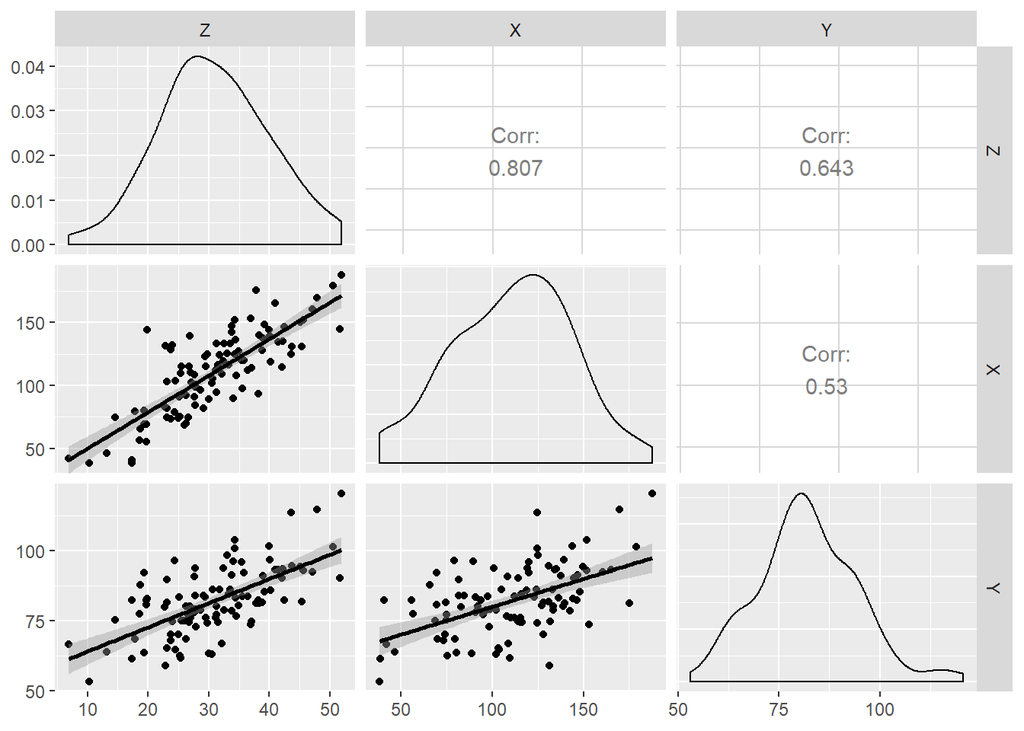

## Association

- Variables \(X,Y\) are *associated*, by virtue of being caused by \(Z\)
  - Relationship can be described by regression

```r
lm( Y ~ X, data = sim) %>% tidy()
## # A tibble: 2 x 5
##   term        estimate std.error statistic  p.value
##   <chr>          <dbl>     <dbl>     <dbl>    <dbl>
## 1 (Intercept)   60.1      3.71       16.2  1.75e-29
## 2 X              0.199    0.0322      6.19 1.44e- 8
```

- *Perfectly OK* to use model for prediction:
  - Predict wildfire severity based on ice cream sales
- *Not OK* to use model for intervention
  - Cannot prevent wildfires by banning ice cream

## Causation

- In an experiment, we can *manipulate* variables
  - Intervention in causal variable propagated to affected variables
  - Intervention in non-causal variable is inconsequential, and breaks up spurious associations

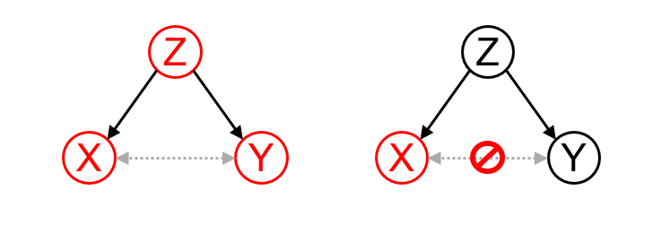

## Example

- Experiment: control causal variable \(Z\)

```r
sim %>%
  mutate( Z = seq( from = min(Z), to = max(Z), length.out = 100),
          X = 20 + 3 * Z + 20*rnorm(100),
          Y = 50 + 1 * Z + 10*rnorm(100) ) %>%
  lm(Y ~ Z, data = .) %>% tidy()
## # A tibble: 2 x 5
##   term        estimate std.error statistic  p.value
##   <chr>          <dbl>     <dbl>     <dbl>    <dbl>
## 1 (Intercept)    50.0     2.43        20.6 2.51e-37
## 2 Z               1.03    0.0755      13.7 1.98e-24
```

## Example (con't)

- Experiment: control non-causal variable \(X\)

```r
sim %>%
  mutate( X = seq(min(X), max(X), length.out = 100))  %>%
  lm(Y ~ X, data = .) %>% tidy()
## # A tibble: 2 x 5
##   term        estimate std.error statistic  p.value
##   <chr>          <dbl>     <dbl>     <dbl>    <dbl>
## 1 (Intercept)  77.3       3.39       22.8  5.84e-41
## 2 X             0.0422    0.0280      1.50 1.36e- 1
```

## Confounding Variables

- *Confounder*: variable that influences both dependent & independent variables, causing *spurious* (i.e. non-causal) association
  - E.g. variable \(Z\) considered previously
- Confounding prevents us from confidently drawing causal inferences from observational data
  - Confounding does not affect predictions
- Effect of *known* confounders can be *controlled* by including them in the model
  - Controlling does not address potential *unknown* confounders

## Example

- Include confounder (\(Z\)) *without* intervention

```r
sim %>%
  mutate( X = 20 + 3 * Z + 20*rnorm(100) )  %>%
  lm(Y ~ X + Z, data = .) %>% tidy()
## # A tibble: 3 x 5
##   term        estimate std.error statistic  p.value
##   <chr>          <dbl>     <dbl>     <dbl>    <dbl>
## 1 (Intercept)  56.0       3.48      16.1   4.21e-29
## 2 X            -0.0374    0.0538    -0.695 4.89e- 1
## 3 Z             0.983     0.198      4.96  3.05e- 6
```

## Simpson's Paradox

- Extreme version of confounding, where association between \(X\) & \(Y\) is *reversed* when additional variable \(Z\) is considered

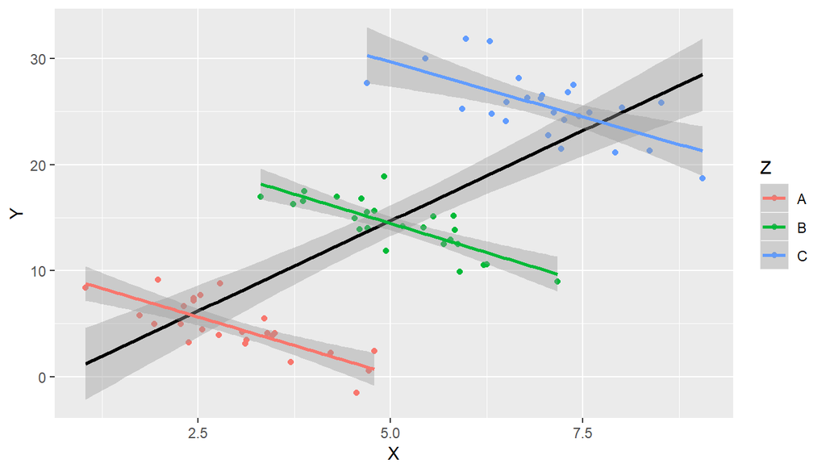

## Example

- 1973 UC Berkeley admissions data
  - Apparent gender bias in acceptance rate

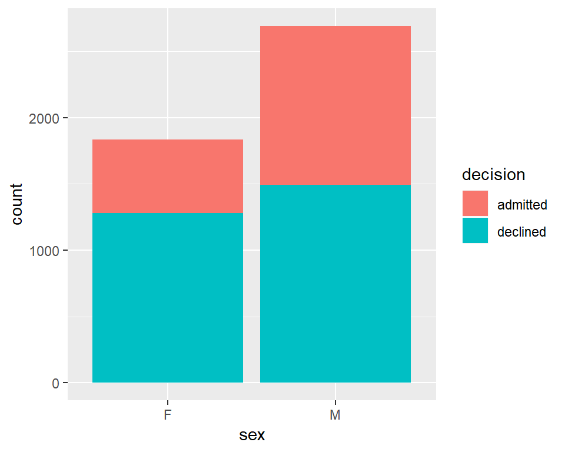

## Example (cont'd)

- Gender bias *reverses* when considering different *departments* (confounder)

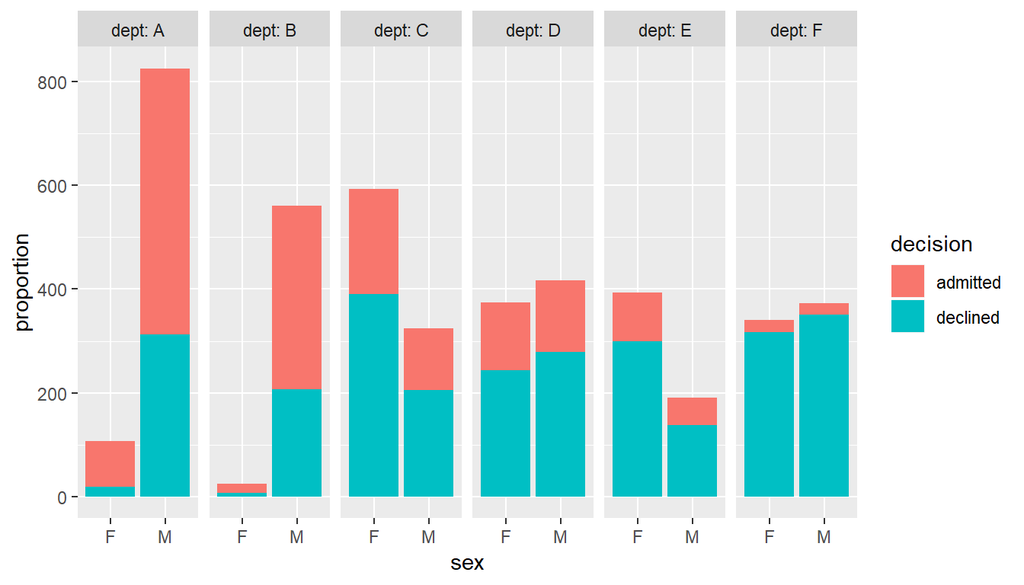

## Randomized Controlled Trials

- Gold standard of scientific evidence is *Randomized Controlled Trial (RCT)*
- *Controll* variables that can be manipulated
  - Variables of *interest* are assigned to desired *treatment*, e.g. drug or placebo
  - *Nuisance* variables are kept constant or distributed evenly (*blocking*), e.g. same gender ratio for each treatment
- *Randomize* for variables that cannot be manipulated
  - Randomly assign subjects to treatments, to account for variables that cannot be controlled (prevent bias)

## Statistical Skepticism

(https://imgs.xkcd.com/comics/correlation.png)